# Casos de Agresiones Sexuales en PR desde el 2012 al 2016

Ian Flores

10 de Febrero del 2018

## Justificación

En Puerto Rico, ocurren múltiples agresiones sexuales a diario. En este mini-reporte no trato de ser exhaustivo con un análisis meramente cuantitativo sobre las agresiones sexuales en la isla, si no fomentar una discusión sobre el tema y que sirva de guia para futuros trabajos. Cabe recalcar que los números reportados a la Policía de Puerto Rico están subestimados. Los datos fueron obtenidos del portal data.pr.gov. El codigo para reproducir estas visualizaciones se encuentra publicado en [GitHub](https://github.com/ian-flores/Crime-Map-PR/blob/master/index.Rmd).

## Distribución Espacial en la Isla

La escala de colores es segun el numero de casos en una región dada. Verde es para las regiones con menos casos reportados entre 2012 y 2016. Amarillo es para las regiones con un número intermedio de casos reportados. Anaranjado es para un número elevado de casos reportados.

[interactive chart not shown]

## Distribución por Año

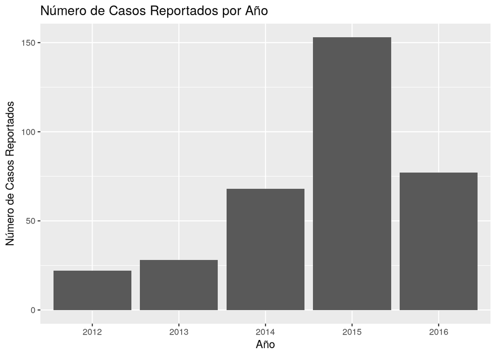

## Distribución por Mes

Esta distribución por mes, es cumulativa por año. Entiendase, es la suma de todos los casos reportados en un mes dado desde el 2012 al 2016.

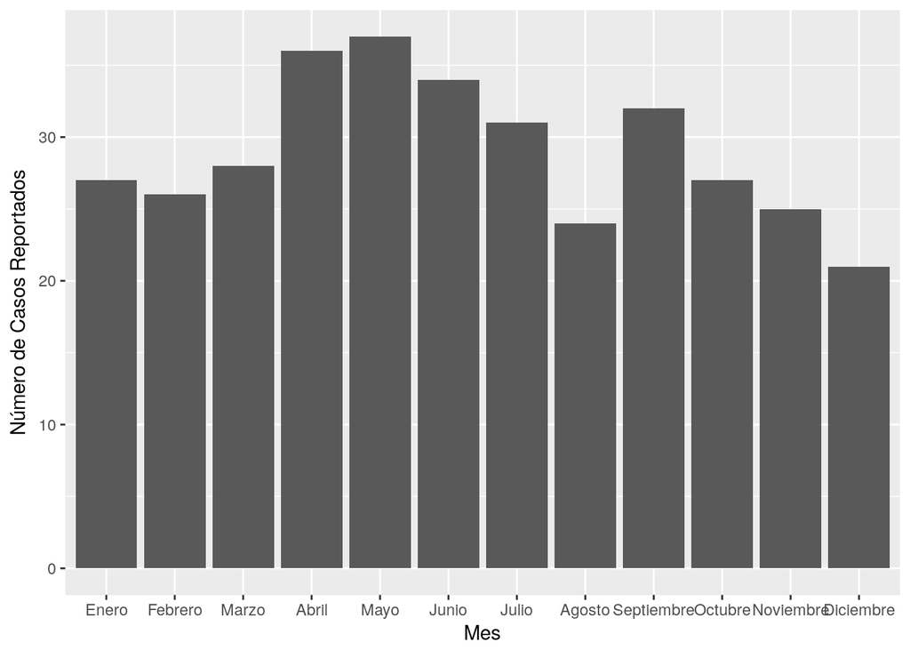

## Distribución por Día

Escogí visualizar la distribución por dia para observar, preliminarmente, si a medida que los días se alejan del dia de pago (quincena), aumentaba o disminuía la incidencia. Esta distribución por dia, es cumulativa por año. Entiendase, es la suma de todos los casos reportados en un dia dado desde el 2012 al 2016.

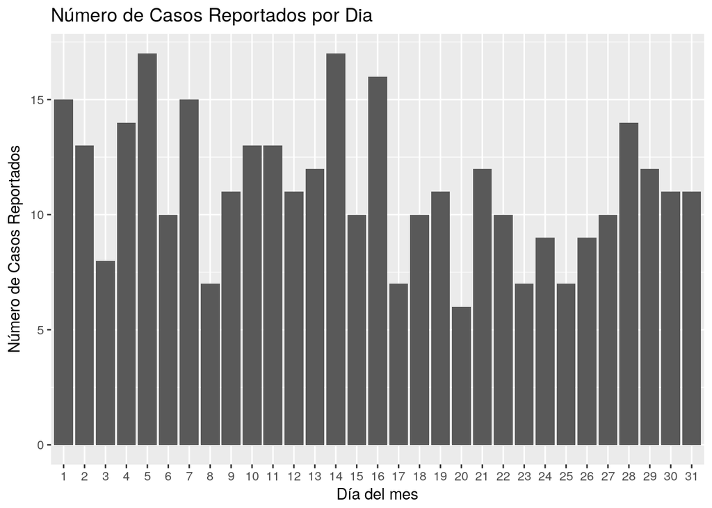

## Distribución por Hora

Esta distribución por hora, es cumulativa por año. Entiendase, es la suma de todos los casos reportados por hora desde el 2012 al 2016. El formato es en formato militar.

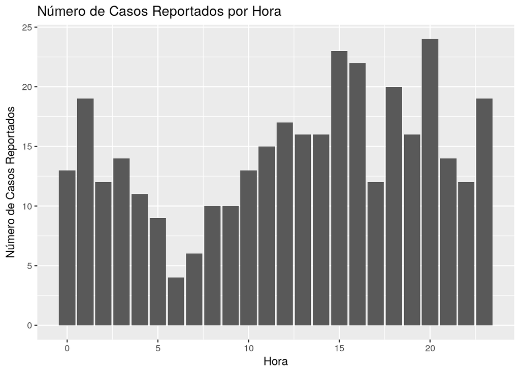

## Distribución por Día de la Semana

Esta distribución por dia de la semana, es cumulativa por año. Entiendase, es la suma de todos los casos reportados en un dia de la semana, dado desde el 2012 al 2016.

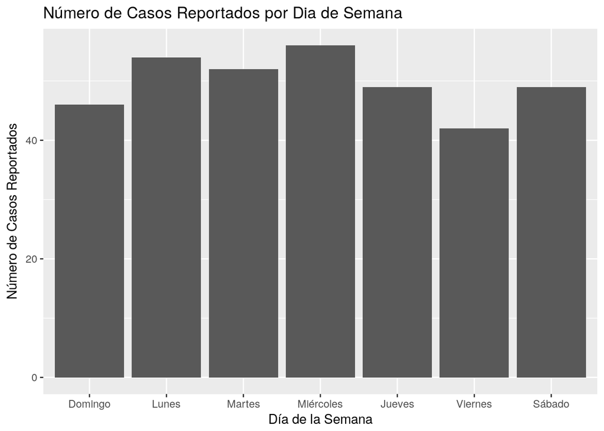